# Ordinal Regressions

Rosie

5/6/2022

## An Introduction to Orginal Regression

Sometimes you have data that is categorized as “low”, “medium”, and “high”. You can turn these into factors for use in a model, but the model will treat them as unrelated, whereas there is probably an underlying distribution behind those values. The probability of “high” is probably closer to the probability of “medium” than to “low”. Or something like that. In order to include this information in the model, you need an ordinal regression.

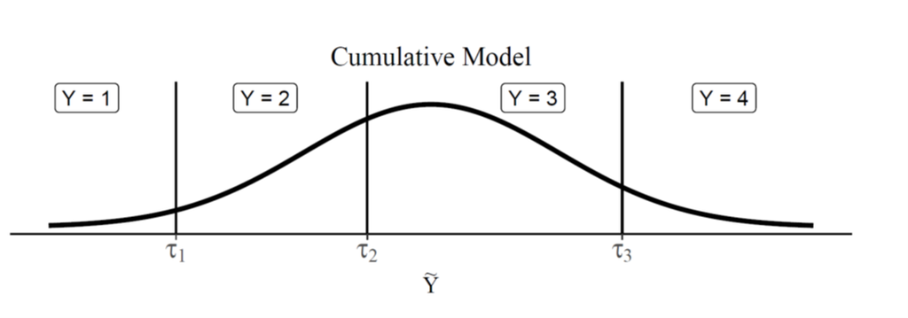

This figure, and much of the material in this tutorial comes from:

Bürkner, P.-C., and M. Vuorre. 2019. Ordinal Regression Models in Psychology: A Tutorial. Advances in Methods and Practices in Psychological Science 2(1):77-101. doi:https://doi.org/10.1177/2515245918823199

This is another good tutorial: https://www.r-bloggers.com/2019/06/how-to-perform-ordinal-logistic-regression-in-r/

```r
library(tidyverse)
library(devtools)
#install_github("sbashevkin/discretewq")
library(discretewq)
library(MASS)
library(brms)
library(effects)
library(lubridate)
library(ordinal)
library(emmeans)
```

Oridinal regressions are basically extentions of logistic regressions. In simple logistic regression, log of odds that an event occurs is modeled as a linear combination of the independent variables. Ordinal regression uses cumulative events for the log of the odds computation. It means that unlike simple logistic regression, ordinal logistic models consider the probability of an event and all the events that are below the focal event in the ordered hierarchy.

There are a number of different types of distributions that can be used with ordinal data.

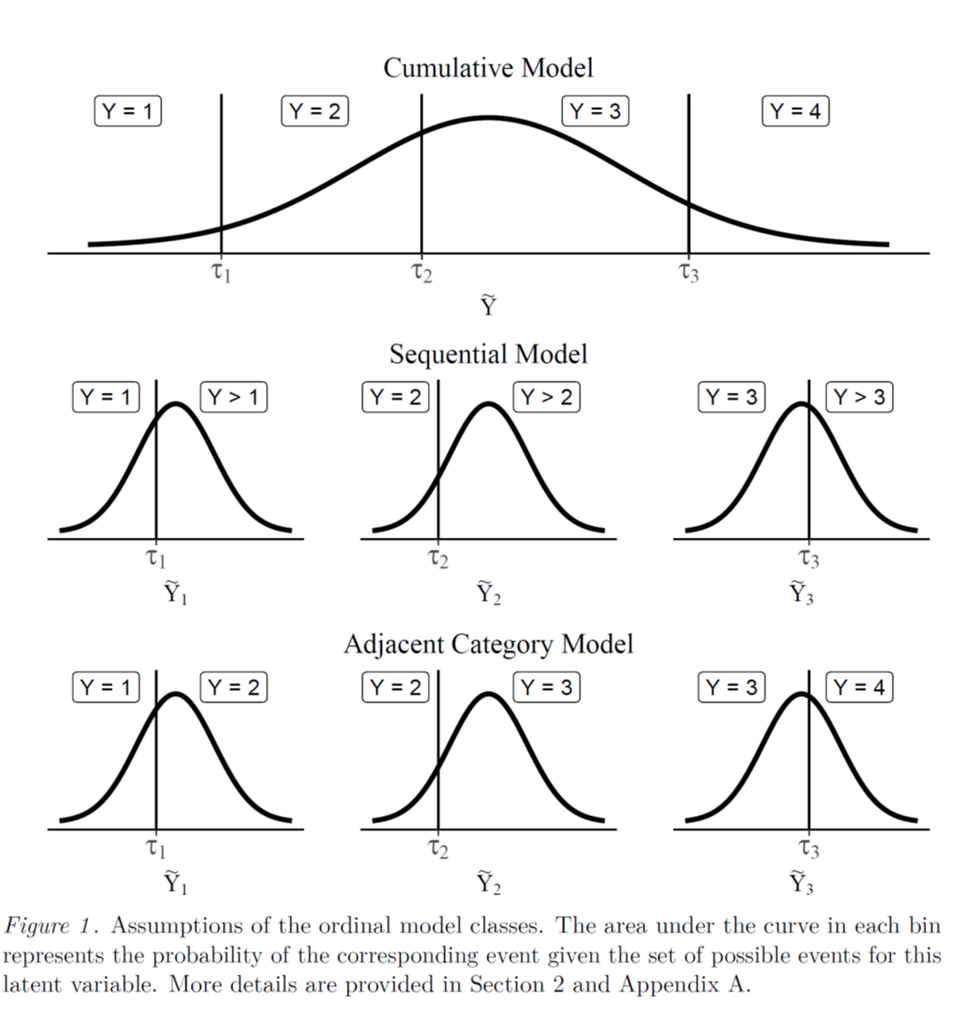

For this example, we are toing to be using visual Microcystis scores collected from various IEP surveys.

Flynn, T., P. Lehman, S. Lesmeister, and S. Waller. 2022. A Visual Scale for Microcystis Bloom Severity. figshare Figure. doi:https://doi.org/10.6084/m9.figshare.19239882.v1

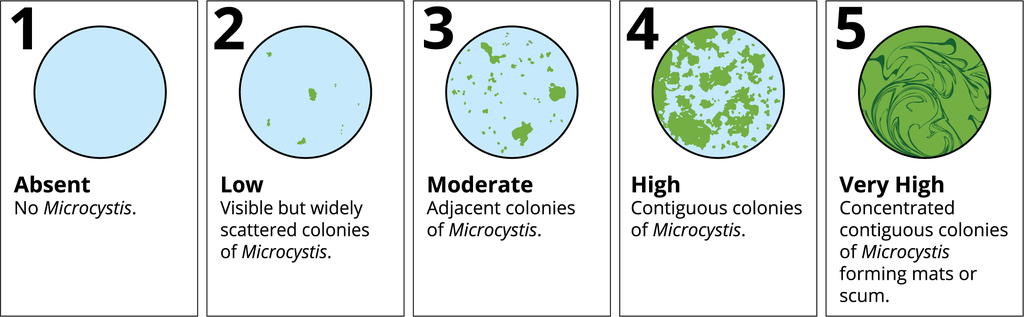

In this case, the cummulative distribution is probably what we want, since “low”, “medium”, and “high” are mutually exclusive.

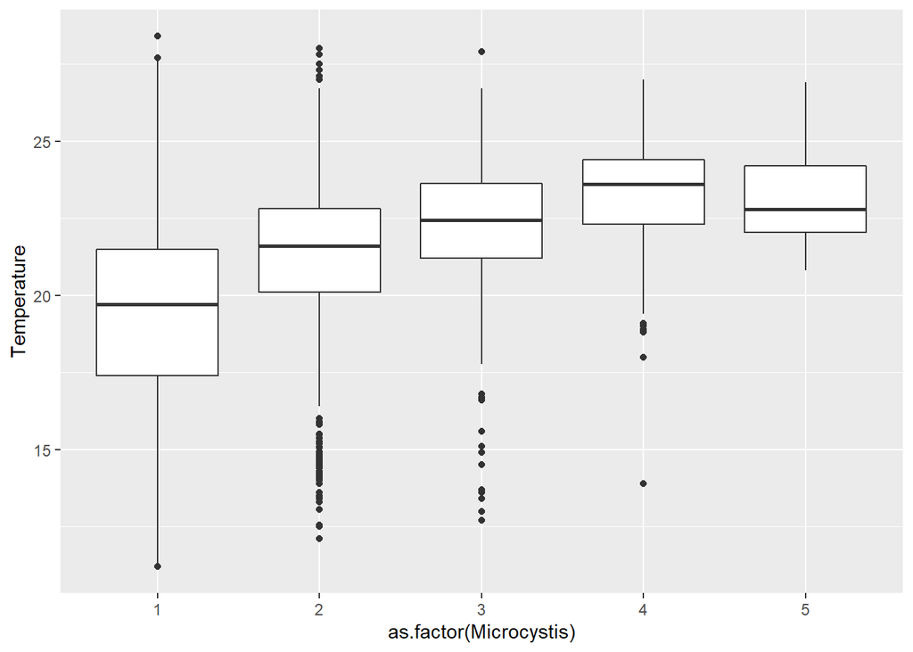

```r
WQ = wq(Sources = c("FMWT", "STN", "EMP"), Start_year = 2015, End_year = 2021) %>%
  dplyr::select(Source, Station, Latitude, Longitude, Date, Depth, Microcystis,
                Secchi, Temperature, Salinity, Conductivity, Month, Season) %>%
  filter(!is.na(Microcystis), Season %in% c("Summer", "Fall"))
View(WQ)

ggplot(WQ, aes(x = as.factor(Microcystis), y = Temperature)) + geom_boxplot()
```

Cool! So it looks as though there is probably a trend between Microcystis observations and water temperature. However, there is some ammount of variation in how people judge microcystis levels. Let’s convert from 5 categories to 3 categories, to try and reduce variability.

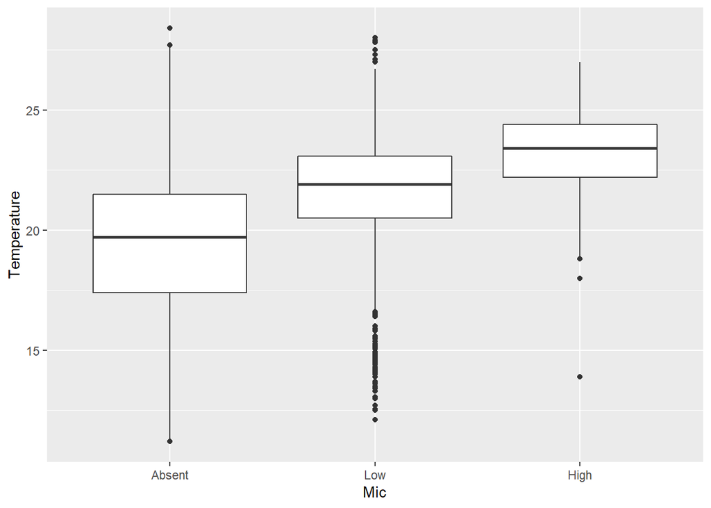

```r
WQ = mutate(WQ, Mic = case_when(Microcystis == 1 ~ "Absent",
                                Microcystis %in% c(2,3) ~ "Low",
                                Microcystis %in% c(4,5)~ "High"),
            Mic = factor(Mic, levels = c("Absent", "Low", "High"), ordered = T))

ggplot(WQ, aes(x = Mic, y = Temperature)) + geom_boxplot()
```

OK, now we can set up our model of temperature versus Microcystis. If we have a simple model, we can use the ‘polr’ function in the MASS package, but the package ‘ordinal’ allows for mixed models and more complicated controls.

```r
mod1 = clm(Mic~Temperature, data = WQ)
summary(mod1)
```

```
## formula: Mic ~ Temperature
## data:    WQ
##
##  link  threshold nobs logLik   AIC     niter max.grad cond.H
##  logit flexible  4812 -3065.90 6137.79 6(0)  3.00e-11 7.8e+04
##
## Coefficients:
##             Estimate Std. Error z value Pr(>|z|)
## Temperature  0.34248    0.01437   23.83   <2e-16 ***
## ---
## Signif. codes:  0 '***' 0.001 '**' 0.01 '*' 0.05 '.' 0.1 ' ' 1
##
## Threshold coefficients:
##            Estimate Std. Error z value
## Absent|Low   7.9649     0.3054   26.08
## Low|High    10.4682     0.3242   32.29
## (9 observations deleted due to missingness)
```

The table displays the value of coefficients and intercepts, and corresponding standard errors z values, and p-values. Holding everything else constant, an increase in Temperature by one degree increases the log odds of Microcystis by 0.3.

THere are multiple values of intercepts depending on the levels of intercept. The intercepts can be interpreted as the expected odds when others variables assume a value of zero. So the Absent|Low intercept takes value of 7.9, indicating that the expected odds of absence when temperature is zero is 7.9 times greater than for Low.

We can plot the effect of temperature:

```r
#Plotting the effects

Effect(focal.predictors = "Temperature",mod1)
```

```
##
## Temperature effect (probability) for Absent
## Temperature
##        11        16        20        24        28
## 0.9851913 0.9230985 0.7531129 0.4366813 0.1645759
##
## Temperature effect (probability) for Low
## Temperature
##         11         16         20         24         28
## 0.01358052 0.07013209 0.22076788 0.46785638 0.54199068
##
## Temperature effect (probability) for High
## Temperature
##          11          16          20          24          28
## 0.001228230 0.006769439 0.026119191 0.095462303 0.293433450
```

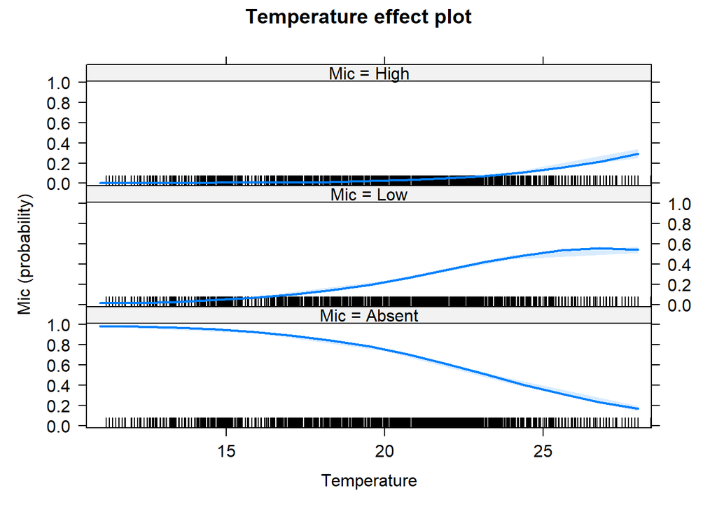

```r
plot(Effect(focal.predictors ="Temperature",mod1))
```

This really lets us see how as temperature increases, probability of High microcystis increases, probability of Low microcystis increases, then levels off, and probability of Absence decreases.

However, there area probably some issues with this model. Temperature is highly correlated with day of the year, and there is probably some spatial autocorrelation going on too. A better model would include multiple predictors and random effects.

```r
#first let's calculate day of year and year to include in the model as a random effect

WQ = mutate(WQ, DOY = yday(Date), Year = as.factor(year(Date)))

mod2 = clmm(Mic ~ Temperature + Secchi + Year + (1|DOY), data = WQ)
summary(mod2)
```

```
## Cumulative Link Mixed Model fitted with the Laplace approximation
##
## formula: Mic ~ Temperature + Secchi + Year + (1 | DOY)
## data:    WQ
##
##  link  threshold nobs logLik   AIC     niter     max.grad cond.H
##  logit flexible  4718 -2425.35 4872.71 665(3495) 1.30e-02 2.5e+06
##
## Random effects:
##  Groups Name        Variance Std.Dev.
##  DOY    (Intercept) 2.042    1.429
## Number of groups:  DOY 168
##
## Coefficients:
##               Estimate Std. Error z value Pr(>|z|)
## Temperature  0.5616482  0.0286895  19.577  < 2e-16 ***
## Secchi       0.0097468  0.0007285  13.378  < 2e-16 ***
## Year2016     0.1793758  0.1489293   1.204   0.2284
## Year2017    -2.7175744  0.2269768 -11.973  < 2e-16 ***
## Year2018     0.1836779  0.1742576   1.054   0.2919
## Year2019    -0.7997375  0.1855894  -4.309 1.64e-05 ***
## Year2020     0.3454841  0.1458239   2.369   0.0178 *
## Year2021     1.5046456  0.2830319   5.316 1.06e-07 ***
## ---
## Signif. codes:  0 '***' 0.001 '**' 0.01 '*' 0.05 '.' 0.1 ' ' 1
##
## Threshold coefficients:
##            Estimate Std. Error z value
## Absent|Low  13.5555     0.6443   21.04
## Low|High    16.9222     0.6841   24.74
## (103 observations deleted due to missingness)
```

Now let’s plot the effects, and do pairwise comparisons between years

```r
allEffects(mod2)
```

```
##  model: Mic ~ Temperature + Secchi + Year
##
## Temperature effect (probability) for Absent
## Temperature
##         11         16         20         24         28
## 0.99892823 0.98252120 0.85601027 0.38602496 0.06234814
##
## Temperature effect (probability) for Low
## Temperature
##          11          16          20          24          28
## 0.001034751 0.016865393 0.138219589 0.561953798 0.596032742
##
## Temperature effect (probability) for High
## Temperature
##           11           16           20           24           28
## 3.701664e-05 6.134089e-04 5.770137e-03 5.202125e-02 3.416191e-01
##
## Secchi effect (probability) for Absent
## Secchi
##         8       100       200       400       500
## 0.9310822 0.8464117 0.6752557 0.2284119 0.1004733
##
## Secchi effect (probability) for Low
## Secchi
##          8        100        200        400        500
## 0.06637049 0.14736654 0.30842229 0.66720378 0.66353015
##
## Secchi effect (probability) for High
## Secchi
##           8         100         200         400         500
## 0.002547314 0.006221753 0.016321987 0.104384335 0.235996597
##
## Year effect (probability) for Absent
## Year
##      2015      2016      2017      2018      2019      2020      2021
## 0.7998936 0.7696354 0.9837488 0.7688718 0.8989277 0.7388781 0.4702810
##
## Year effect (probability) for Low
## Year
##       2015       2016       2017       2018       2019       2020       2021
## 0.19154898 0.22014307 0.01568156 0.22086308 0.09720795 0.24907563 0.49230991
##
## Year effect (probability) for High
## Year
##         2015         2016         2017         2018         2019         2020
## 0.0085574258 0.0102215208 0.0005696401 0.0102651367 0.0038643149 0.0120463090
##         2021
## 0.0374090453
```

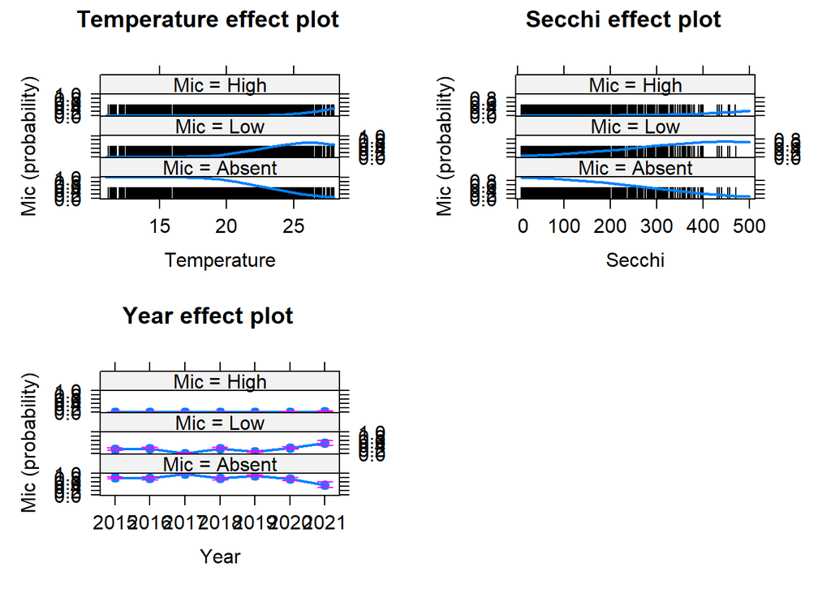

```r
plot(allEffects(mod2))
```

```r
emmeans(mod2, pairwise ~ Year)
```

```
## $emmeans
##  Year emmean    SE  df asymp.LCL asymp.UCL
##  2015  -3.07 0.183 Inf     -3.43     -2.71
##  2016  -2.89 0.175 Inf     -3.23     -2.55
##  2017  -5.79 0.247 Inf     -6.27     -5.30
##  2018  -2.89 0.171 Inf     -3.22     -2.55
##  2019  -3.87 0.192 Inf     -4.24     -3.49
##  2020  -2.72 0.172 Inf     -3.06     -2.39
##  2021  -1.56 0.257 Inf     -2.07     -1.06
##
## Confidence level used: 0.95
##
## $contrasts
##  contrast    estimate    SE  df z.ratio p.value
##  2015 - 2016  -0.1794 0.149 Inf  -1.204  0.8927
```

[output cut: 22 more lines]

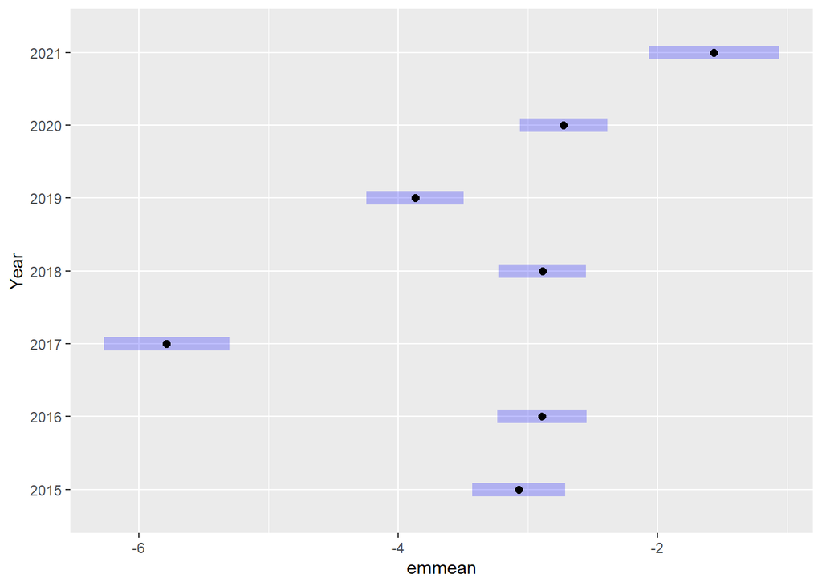

```r
plot(emmeans(mod2, pairwise ~ Year))
```

## Bayesian Approach

We can also use a Bayesian approach.

We will be using the ‘brms’ package, which uses stan on the back end.

There are a lot of great vinettes to help you set it up. The “troubleshooting” one is my favorite.

```r
#Running these models takes FOREVER, so we're going to limit it to just 2020, to make life easier

WQ2020 = filter(WQ, Year == "2020")

M5.1 = brm(Mic ~ Temperature + Secchi +  (1|DOY), data = WQ2020, family = cumulative,
           iter = 1000, backend = "cmdstanr",
           control = list(max_treedepth = 15),
           chains = 2)
```

```
## Running MCMC with 2 sequential chains...
##
## Chain 1 Iteration:   1 / 1000 [  0%]  (Warmup)
## Chain 1 Iteration: 100 / 1000 [ 10%]  (Warmup)
## Chain 1 Iteration: 200 / 1000 [ 20%]  (Warmup)
## Chain 1 Iteration: 300 / 1000 [ 30%]  (Warmup)
## Chain 1 Iteration: 400 / 1000 [ 40%]  (Warmup)
## Chain 1 Iteration: 500 / 1000 [ 50%]  (Warmup)
## Chain 1 Iteration: 501 / 1000 [ 50%]  (Sampling)
## Chain 1 Iteration: 600 / 1000 [ 60%]  (Sampling)
## Chain 1 Iteration: 700 / 1000 [ 70%]  (Sampling)
## Chain 1 Iteration: 800 / 1000 [ 80%]  (Sampling)
## Chain 1 Iteration: 900 / 1000 [ 90%]  (Sampling)
## Chain 1 Iteration: 1000 / 1000 [100%]  (Sampling)
## Chain 1 finished in 282.7 seconds.
## Chain 2 Iteration:   1 / 1000 [  0%]  (Warmup)
## Chain 2 Iteration: 100 / 1000 [ 10%]  (Warmup)
## Chain 2 Iteration: 200 / 1000 [ 20%]  (Warmup)
## Chain 2 Iteration: 300 / 1000 [ 30%]  (Warmup)
## Chain 2 Iteration: 400 / 1000 [ 40%]  (Warmup)
## Chain 2 Iteration: 500 / 1000 [ 50%]  (Warmup)
## Chain 2 Iteration: 501 / 1000 [ 50%]  (Sampling)
## Chain 2 Iteration: 600 / 1000 [ 60%]  (Sampling)
## Chain 2 Iteration: 700 / 1000 [ 70%]  (Sampling)
## Chain 2 Iteration: 800 / 1000 [ 80%]  (Sampling)
## Chain 2 Iteration: 900 / 1000 [ 90%]  (Sampling)
## Chain 2 Iteration: 1000 / 1000 [100%]  (Sampling)
## Chain 2 finished in 349.3 seconds.
##
## Both chains finished successfully.
## Mean chain execution time: 316.0 seconds.
## Total execution time: 634.3 seconds.
```

```r
save(M5.1, file = "M5.1.RData")
```

So, it worked, but it takes a while. The more complicated the model, the longer it takes.

```r
summary(M5.1)
```

```
##  Family: cumulative
##   Links: mu = logit; disc = identity
## Formula: Mic ~ Temperature + Secchi + (1 | DOY)
##    Data: WQ2020 (Number of observations: 742)
##   Draws: 2 chains, each with iter = 500; warmup = 0; thin = 1;
##          total post-warmup draws = 1000
##
## Group-Level Effects:
## ~DOY (Number of levels: 68)
##               Estimate Est.Error l-95% CI u-95% CI Rhat Bulk_ESS Tail_ESS
## sd(Intercept)     2.11      0.27     1.62     2.69 1.01      242      460
##
## Population-Level Effects:
##              Estimate Est.Error l-95% CI u-95% CI Rhat Bulk_ESS Tail_ESS
## Intercept[1]    19.01      1.82    15.64    22.72 1.00      379      639
## Intercept[2]    23.31      1.96    19.71    27.35 1.00      387      570
## Temperature      0.86      0.09     0.70     1.03 1.00      380      654
## Secchi           0.01      0.00     0.00     0.01 1.00      898      943
##
## Family Specific Parameters:
##      Estimate Est.Error l-95% CI u-95% CI Rhat Bulk_ESS Tail_ESS
## disc     1.00      0.00     1.00     1.00   NA       NA       NA
##
## Draws were sampled using sample(hmc). For each parameter, Bulk_ESS
## and Tail_ESS are effective sample size measures, and Rhat is the potential
## scale reduction factor on split chains (at convergence, Rhat = 1).
```

```r
cex = conditional_effects(M5.1, categorical = TRUE)
 conditional_effects(M5.1, categorical = TRUE)
```

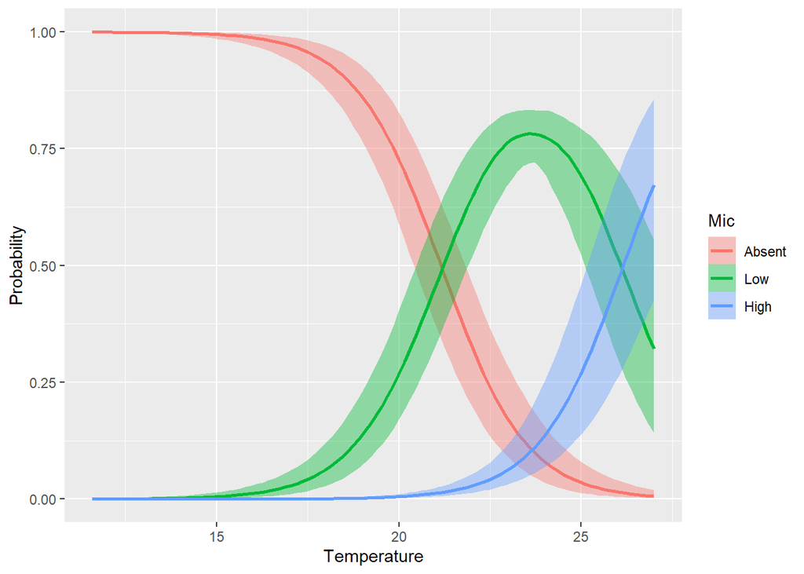

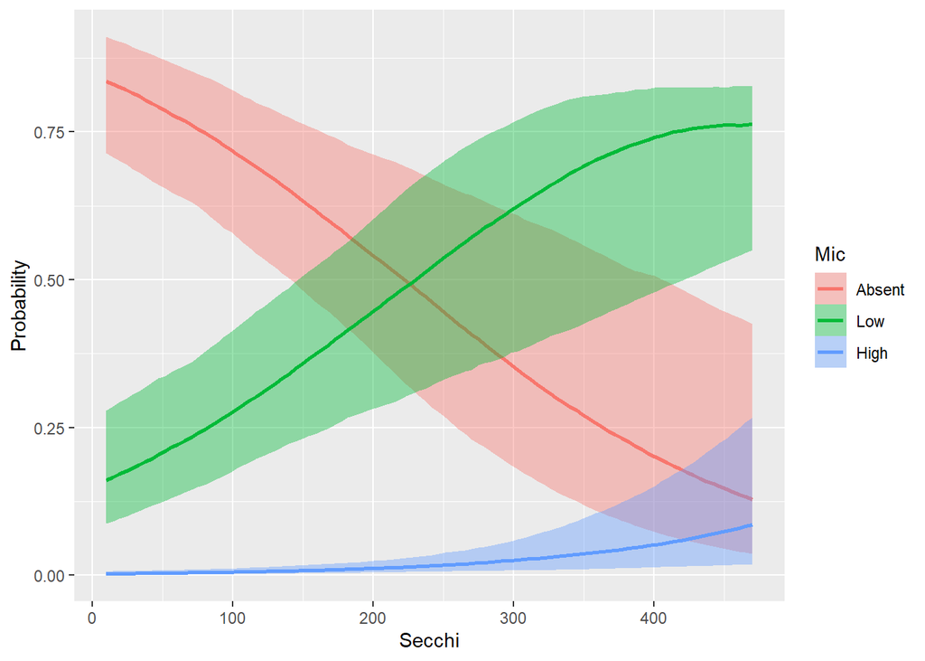